# Lab 5: RNA-seq differential expression analysis

Leslie Myint

April 26, 2016

#### Package version: BiocStyle 1.8.0

# 1 Overview

We will go over three widely used RNA-seq differential expression packages available in Bioconductor.

# 2 Obtaining count matrices

Very often we’ll start with fastq files that we’ll align with a spliced aligner such as TopHat to get a SAM/BAM file. Let’s look at how to obtain a matrix of count information with samples along the columns and genes/transcripts along the rows.

I downloaded the S. cerevisiae GTF file from Ensembl: ftp://ftp.ensembl.org/pub/release-84/gtf/saccharomyces_cerevisiae/Saccharomyces_cerevisiae.R64-1-1.84.gtf.gz. About the GTF file format: http://useast.ensembl.org/info/website/upload/gff.html.

Let’s first create a database of known transcripts in yeast with `makeTxDbFromGFF`:

```r
library(GenomicFeatures)
gtfFile <- list.files("~/gtf", full.names = TRUE)
yeastTxdb <- makeTxDbFromGFF(gtfFile, format = "gtf")
```

```
## Import genomic features from the file as a GRanges object ...
```

```
## OK
```

```
## Prepare the 'metadata' data frame ...
```

```
## OK
```

```
## Make the TxDb object ...
```

```
## OK
```

For each gene, we can obtain the exons overlapping that gene:

```r
ebg <- exonsBy(yeastTxdb, by = "gene") # by = "tx" for exons by transcript
```

We see that there are 7126 genes in this list. Now let’s count the number of reads mapping to each gene.

```r
library(GenomicAlignments)
bamfiles <- BamFileList(list.files("~/statgenomics/hw2/", pattern = "accepted.*.bam", full.names = TRUE))
summex <- summarizeOverlaps(features = ebg, reads = bamfiles, mode = "Union", ignore.strand = TRUE)
summary(assay(summex, "counts"))
```

```
##  accepted_hits.bam
##  Min.   :0
##  1st Qu.:0
##  Median :0
##  Mean   :0
##  3rd Qu.:0
##  Max.   :0
```

The reference sequence names in my BAM file and the GTF file don’t match.

```r
seqinfo(bamfiles)
```

```
## Seqinfo object with 17 sequences from an unspecified genome:
##   seqnames seqlengths isCircular genome
##   Scchr01      230208       <NA>   <NA>
##   Scchr02      813178       <NA>   <NA>
##   Scchr03      316617       <NA>   <NA>
##   Scchr04     1531917       <NA>   <NA>
##   Scchr05      576869       <NA>   <NA>
##   ...             ...        ...    ...
##   Scchr13      924429       <NA>   <NA>
##   Scchr14      784333       <NA>   <NA>
##   Scchr15     1091289       <NA>   <NA>
##   Scchr16      948062       <NA>   <NA>
##   Scmito        85779       <NA>   <NA>
```

```r
seqinfo(ebg)
```

```
## Seqinfo object with 17 sequences (1 circular) from an unspecified genome; no seqlengths:
##   seqnames seqlengths isCircular genome
##   I              <NA>       <NA>   <NA>
##   II             <NA>       <NA>   <NA>
##   III            <NA>       <NA>   <NA>
##   IV             <NA>       <NA>   <NA>
##   V              <NA>       <NA>   <NA>
##   ...             ...        ...    ...
##   XIII           <NA>       <NA>   <NA>
##   XIV            <NA>       <NA>   <NA>
##   XV             <NA>       <NA>   <NA>
##   XVI            <NA>       <NA>   <NA>
##   Mito           <NA>       TRUE   <NA>
```

We can remap these names using the `renameSeqLevels` function in the `GenomeInfoDb` package.

```r
library(GenomeInfoDb)
newnames <- seqlevels(bamfiles)
names(newnames) <- seqlevels(ebg)
seqlevels(ebg)
```

```
##  [1] "I"    "II"   "III"  "IV"   "V"    "VI"   "VII"  "VIII" "IX"   "X"
## [11] "XI"   "XII"  "XIII" "XIV"  "XV"   "XVI"  "Mito"
```

```r
ebg <- renameSeqlevels(ebg, newnames)
seqlevels(ebg)
```

```
##  [1] "Scchr01" "Scchr02" "Scchr03" "Scchr04" "Scchr05" "Scchr06" "Scchr07"
##  [8] "Scchr08" "Scchr09" "Scchr10" "Scchr11" "Scchr12" "Scchr13" "Scchr14"
## [15] "Scchr15" "Scchr16" "Scmito"
```

Now we can retry the counting. More information on `summarizeOverlaps`: http://bioconductor.org/packages/release/bioc/vignettes/GenomicAlignments/inst/doc/summarizeOverlaps.pdf.

```r
summex <- summarizeOverlaps(features = ebg, reads = bamfiles, mode = "Union", ignore.strand = TRUE)
summary(assay(summex, "counts"))
```

```
##  accepted_hits.bam
##  Min.   :    0.0
##  1st Qu.:    8.0
##  Median :   35.0
##  Mean   :  158.3
##  3rd Qu.:   89.0
##  Max.   :35815.0
```

# 3 Loading data for differential expression analysis

We’ll be looking at a dataset mentioned in section 4.2.3 of the edgeR user’s guide. The study looks at gene expression in Arabidopsis thaliana in the presence of a mutant form of Pseudomonas syringae. The control group was exposed to a mock pathogen.

```r
install.packages("NBPSeq")
```

The data in the `NBPSeq` package is stored in the `arab` object that is available with `data(arab)`.

```r
library(NBPSeq)
data(arab)
countmat <- arab
coldata <- data.frame(treatment = factor(rep(c(0,1), each = 3), levels = c(0,1), labels = c("mock", "hrcctreated")))
```

# 4 DESeq

For a detailed workflow using the `DESeq2` package, see http://www.bioconductor.org/help/workflows/rnaseqGene/.

We first create a `DESeqDataSet` object from the count matrix.

```r
library(DESeq2)
dds <- DESeqDataSetFromMatrix(countData = countmat, colData = coldata, design = ~treatment)
```

Let’s see if we need to filter out genes from our dataset due to uniformly low counts.

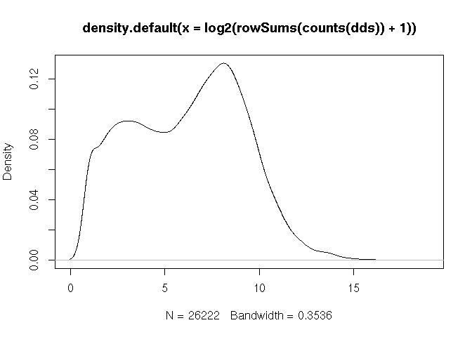

```r
plot(density(log2(rowSums(counts(dds))+1)))
```

```r
keep <- rowSums(counts(dds)) > 1
table(keep)
```

```
## keep
## FALSE  TRUE
##  1302 24920
```

```r
dds <- dds[keep,]
```

The regularized-logarithm (rlog) transform is a variance-stabilizing transformation that allows us to visualize the distance between samples with a PCA plot.

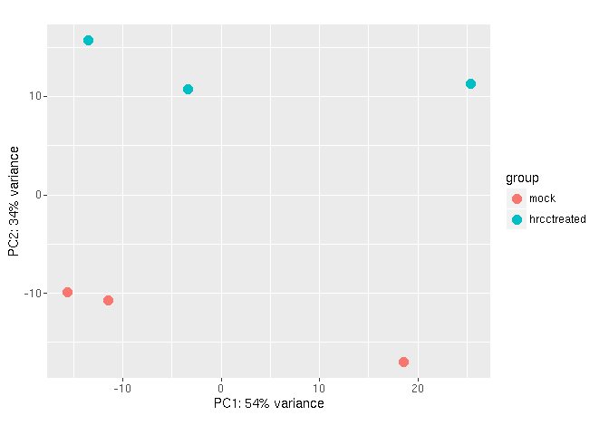

```r
rld <- rlog(dds)
plotPCA(rld, intgroup = "treatment")
```

We can perform differential expression analysis on the untransformed data with the `DESeq` function.

```r
dds <- DESeq(dds)
res <- results(dds)
res <- res[order(res$padj),]
head(res)
```

```
## log2 fold change (MAP): treatment hrcctreated vs mock
## Wald test p-value: treatment hrcctreated vs mock
## DataFrame with 6 rows and 6 columns
##            baseMean log2FoldChange     lfcSE      stat       pvalue
##           <numeric>      <numeric> <numeric> <numeric>    <numeric>
## AT5G64120 1784.1407       3.570059 0.2335096  15.28870 9.094771e-53
## AT2G19190  354.8943       4.210116 0.3006284  14.00439 1.465379e-44
## AT4G12490 2532.5606       3.632291 0.2736583  13.27309 3.316320e-40
## AT4G12500 2997.5955       4.064204 0.3100970  13.10623 3.032880e-39
## AT2G43620 2087.9523       3.030600 0.2381649  12.72480 4.305977e-37
## AT3G46280  586.4306       4.403938 0.3575450  12.31716 7.322864e-35
##                   padj
##              <numeric>
## AT5G64120 1.117474e-48
## AT2G19190 9.002553e-41
## AT4G12490 1.358254e-36
## AT4G12500 9.316249e-36
## AT2G43620 1.058151e-33
## AT3G46280 1.499601e-31
```

```r
summary(res)
```

```
##
## out of 24920 with nonzero total read count
## adjusted p-value < 0.1
## LFC > 0 (up)     : 552, 2.2%
## LFC < 0 (down)   : 478, 1.9%
## outliers [1]     : 207, 0.83%
## low counts [2]   : 12426, 50%
## (mean count < 17)
## [1] see 'cooksCutoff' argument of ?results
## [2] see 'independentFiltering' argument of ?results
```

We can estimate and adjust for batch effects with a version of `sva` adapted for sequencing.

```r
library(sva)
dds <- DESeqDataSetFromMatrix(countData = countmat, colData = coldata, design = ~treatment)
dds <- estimateSizeFactors(dds)
dat <- counts(dds, normalized = TRUE)
idx <- rowSums(dat) > 1
dat <- dat[idx,]
modmatFull <- model.matrix(~treatment, colData(dds))
modmatNull <- model.matrix(~1, colData(dds))
svseq <- svaseq(dat, modmatFull, modmatNull)
```

```
## Number of significant surrogate variables is:  1
## Iteration (out of 5 ):1  2  3  4  5
```

```r
ddssva <- dds
ddssva$SV1 <- svseq$sv
design(ddssva) <- ~ SV1 + treatment
ddssva <- DESeq(ddssva)
ressva <- results(ddssva)
ressva <- ressva[order(ressva$padj),]
head(ressva)
```

```
## log2 fold change (MAP): treatment hrcctreated vs mock
## Wald test p-value: treatment hrcctreated vs mock
## DataFrame with 6 rows and 6 columns
##            baseMean log2FoldChange     lfcSE      stat       pvalue
##           <numeric>      <numeric> <numeric> <numeric>    <numeric>
## AT2G19190  354.8943       4.232947 0.3151566  13.43125 3.966727e-41
## AT3G46280  586.4306       4.480434 0.3457667  12.95797 2.117810e-38
## AT5G64120 1784.1407       3.516545 0.2767201  12.70795 5.341693e-37
## AT4G12500 2997.5955       4.000049 0.3220354  12.42115 2.006606e-35
## AT1G51800  448.5456       3.764431 0.3073624  12.24753 1.731847e-34
## AT4G12490 2532.5606       3.578401 0.2963760  12.07386 1.451706e-33
##                   padj
##              <numeric>
## AT2G19190 4.956822e-37
## AT3G46280 1.323207e-34
## AT5G64120 2.224993e-33
## AT4G12500 6.268637e-32
## AT1G51800 4.328231e-31
## AT4G12490 3.023419e-30
```

```r
summary(ressva)
```

```
##
## out of 26222 with nonzero total read count
## adjusted p-value < 0.1
## LFC > 0 (up)     : 661, 2.5%
## LFC < 0 (down)   : 529, 2%
## outliers [1]     : 0, 0%
## low counts [2]   : 13726, 52%
## (mean count < 16)
## [1] see 'cooksCutoff' argument of ?results
## [2] see 'independentFiltering' argument of ?results
```

## 4.1 Visualizing results

We can plot the actual sample counts for selected genes.

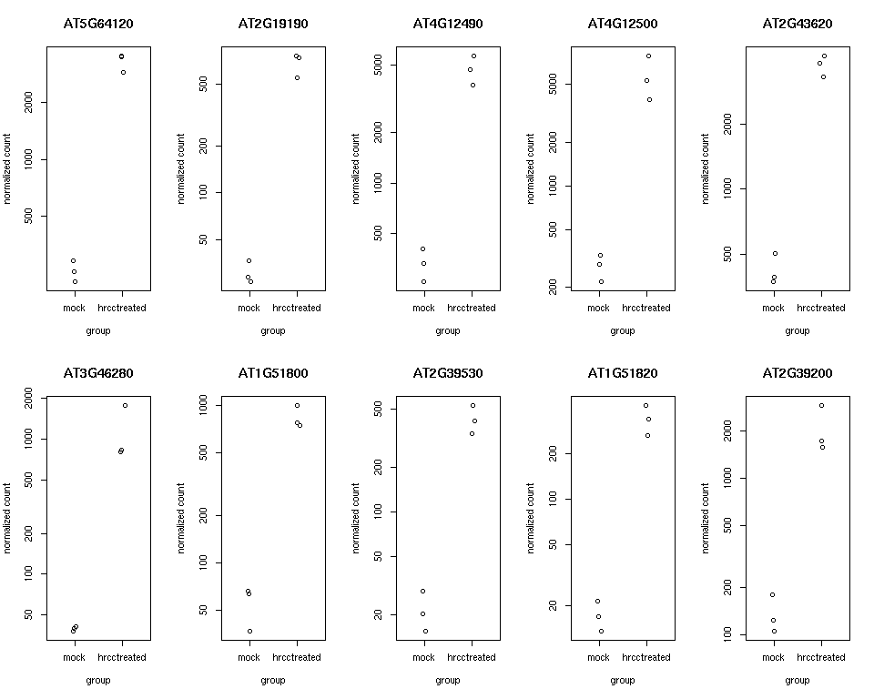

```r
topGenes <- rownames(res)[order(res$padj)][1:10]
par(mfrow = c(2,5))
for (i in 1:10)
    plotCounts(dds, gene = topGenes[i], intgroup = "treatment")
```

Genes with an adjusted p value below the specified threshold will be colored red.

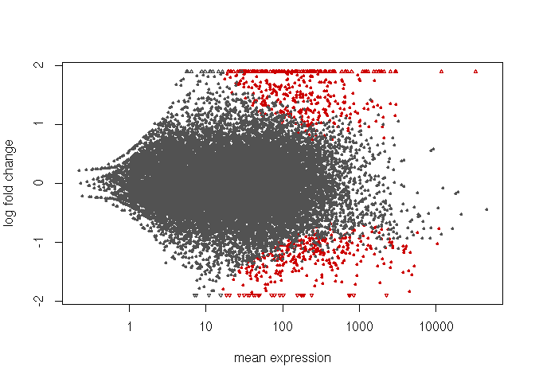

```r
par(mfrow = c(1,1))
plotMA(res, alpha = 0.05)
```

Genes with very low counts can cause spikes in the p-value distribution, so we can remove them to get a better picture of the overall distribution of p-values without such outliers.

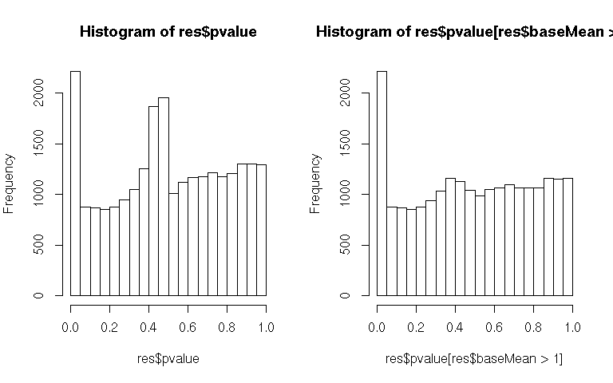

```r
par(mfrow = c(1,2))
hist(res$pvalue)
hist(res$pvalue[res$baseMean > 1])
```

# 5 edgeR

edgeR user’s guide: https://bioconductor.org/packages/release/bioc/vignettes/edgeR/inst/doc/edgeRUsersGuide.pdf

```r
library(edgeR)
dge <- DGEList(counts = countmat, group = coldata$treatment)
```

Let’s evaluate if filtering is needed. We’ll keep genes that have at least one read per million (cpm) in at least one sample in each condition.

```r
keep <- rowSums(cpm(dge)[,1:3] > 1) >= 1 & rowSums(cpm(dge)[,4:6] > 1) >= 1
table(keep)
```

```
## keep
## FALSE  TRUE
##  6213 20009
```

We’ll subset the `dge` object given the above filtering, but we must also have the library sizes recalculated with `keep.lib.sizes = FALSE`.

```r
dge <- dge[keep, , keep.lib.sizes=FALSE]
```

We apply TMM normalization (trimmed mean of M-values) to estimate effective library sizes that account for variations in RNA composition.

```r
dge <- calcNormFactors(dge)
```

When we model count data with a negative binomial distribution, the square root of the dispersion parameter is actually the biological coefficient of variation.

$$\mathrm{Total CV}^2 = \mathrm{Technical CV}^2 + \mathrm{Biological CV}^2$$

We estimate this biological coefficient of variation with `estimateDisp`.

```r
design <- model.matrix(~treatment, data = coldata)
dge <- estimateDisp(dge, design)
```

`edgeR` offers two approaches for differential expression testing: generalized linear model (GLM) likelihood ratio tests (LRT) and quasi-likelihood (QL) F-tests. The package authors recommend the QL F-test because it incorporates the uncertainity in the estimation of the negative binomial dispersion parameter and has shown more reliable error rate control with small sample sizes.

For GLM likelihood ratio tests, we use `glmFit` and `glmLRT`.

```r
fit <- glmFit(dge, design)
lrt <- glmLRT(fit, coef = 2)
topTags(lrt)
```

```
## Coefficient:  treatmenthrcctreated
##              logFC    logCPM        LR       PValue          FDR
## AT2G19190 4.541411  7.389258 105.84273 7.982560e-25 1.597230e-20
## AT2G44370 5.429440  5.213742  95.49154 1.485248e-22 1.485916e-18
## AT3G55150 5.773385  4.909977  93.09287 4.989708e-22 3.327969e-18
## AT1G51820 4.380103  6.384043  90.48495 1.863891e-21 9.323650e-18
## AT4G12500 4.387592 10.438733  90.01643 2.361910e-21 9.451890e-18
## AT3G46280 4.913963  8.122315  88.32610 5.550634e-21 1.851044e-17
## AT2G39380 4.942334  5.791458  88.01725 6.488615e-21 1.854724e-17
## AT5G64120 3.747973  9.701267  87.57987 8.094443e-21 2.024521e-17
## AT2G39530 4.344230  6.721550  84.87045 3.185688e-20 7.082492e-17
## AT4G12490 3.870015 10.201133  84.26289 4.331698e-20 8.667294e-17
```

For QL F-tests, we use `glmQLFit` and `glmQLFTest`.

```r
fit <- glmQLFit(dge, design)
qlf <- glmQLFTest(fit, coef = 2)
topTags(qlf)
```

```
## Coefficient:  treatmenthrcctreated
##              logFC    logCPM        F       PValue         FDR
## AT2G44370 5.429352  5.213742 148.9515 2.063379e-07 0.001503606
## AT2G19190 4.540710  7.389258 148.4208 2.099020e-07 0.001503606
## AT3G55150 5.777271  4.909977 146.2271 2.254395e-07 0.001503606
## AT1G51820 4.377409  6.384043 130.2148 3.922825e-07 0.001962295
## AT2G39380 4.944855  5.791458 118.6974 6.086692e-07 0.002007169
## AT5G64120 3.747725  9.701267 114.2259 7.296599e-07 0.002007169
## AT2G39530 4.346810  6.721550 111.7845 8.078378e-07 0.002007169
## AT3G46280 4.913962  8.122315 110.0903 8.680112e-07 0.002007169
## AT4G12500 4.387666 10.438733 109.1732 9.028198e-07 0.002007169
## AT4G12490 3.869732 10.201133 105.7228 1.049664e-06 0.002100272
```

**Note**: how can we adjust the design matrix so that our analysis also accounts for potential batch effects?

# 6 voom

See Chapter 15 of limma user’s guide: https://bioconductor.org/packages/release/bioc/vignettes/limma/inst/doc/usersguide.pdf

We can start with an `edgeR` object so that we can easily apply TMM normalization to adjust for variations in RNA composition. The `voom` method transforms counts into counts-per-million (cpm) and also computes inverse-variance weights for use in linear modeling.

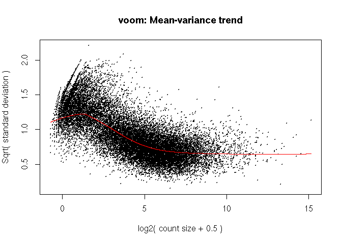

```r
library(limma)
library(edgeR)
dge <- DGEList(counts = countmat)
dge <- calcNormFactors(dge)
design <- model.matrix(~treatment, data = coldata)
v <- voom(dge, design, plot = TRUE)
```

The resulting object contains all of the information needed to continue with the remainder of the standard `limma` pipeline.

```r
fit <- lmFit(v, design)
fit <- eBayes(fit)
toptab <- topTable(fit, coef = 2, number = Inf)
```

Another approach is to use a modified version of the `voom` procedure with estimates sample specific quality weights in order to downweight lower quality samples.

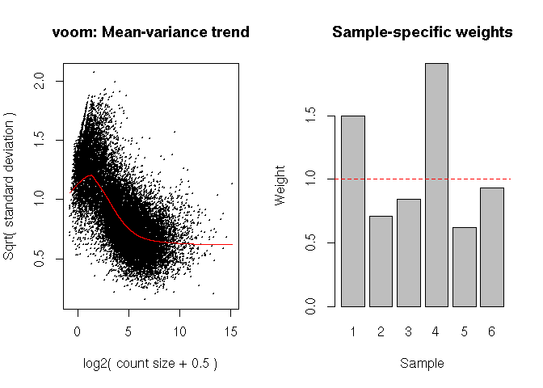

```r
vqw <- voomWithQualityWeights(dge, design = design, normalization = "none", plot = TRUE)
```

```r
vfit2 <- lmFit(vqw)
vfit2 <- eBayes(vfit2)
toptab2 <- topTable(vfit2, coef = 2, number = Inf)
```

# 7 Points to keep in mind

- Make note of when you make choices in your analysis. How sensitive are your final results to that choice? It may be worthwhile to run a sensitivity analysis on that parameter. How stable is the ranking of top differentially expressed genes?
- How do we have more confidence in our results?
  - It is nice to look at the top genes in several ways. Some ways are computational: the original counts across samples, where this gene falls on an MA plot, average expression, and expression variability. Some ways might require external information–are they other qualities that you would expect of your top genes?
  - On a similar note, you might expect low ranking genes to have the opposite qualities.
  - Do different methods rank genes similarly?